# R für Einsteiger: Musterlösungen

Kapitel 15: Grundlagen der Regressionsanalyse

*Diese Musterlösung wurde erstellt von Peter Hähner (Ruhr-Universität Bochum).*

*(c) Luhmann: R fÃ¼r Einsteiger, 5. Aufl., Beltz, 2020*

## Vorbereitungen

Setzen Sie ein Arbeitsverzeichnis oder legen Sie ein entsprechendes R-Projekt an (Kap. 23).

Laden Sie dann die Datei `erstis.RData`.

```r
load("erstis.RData")
```

Laden Sie die benötigten Pakete (ggf. müssen Sie diese vorab noch installieren).

```r
library(psych)
library(car)
library(tidyverse)
```

## Aufgabe 1: Modell 1

Berechnen Sie eine lineare Regression mit guter vs.Â schlechter Stimmung (`gs.1`) als abhängige Variable und ruhiger vs.Â unruhiger Stimmung (`ru.1`) als Prädiktor. Bestimmen Sie den vorhergesagten `gs.1`-Stimmungswert für eine Person mit einem `ru.1`-Stimmungswert von 4.

```r
# Modell schÃ¤tzen
modell.1 <- lm(gs.1 ~ ru.1, data = erstis)

# Vorhergesagten Wert bestimmen
predict(modell.1, list(ru.1 = 4))
```

```
##        1
## 4.181892
```

## Aufgabe 2: Modell 2

Nehmen Sie zusätzlich den Prädiktor `wm.1` (wache vs.Â müde Stimmung) auf. Überprüfen Sie die Modellannahmen.

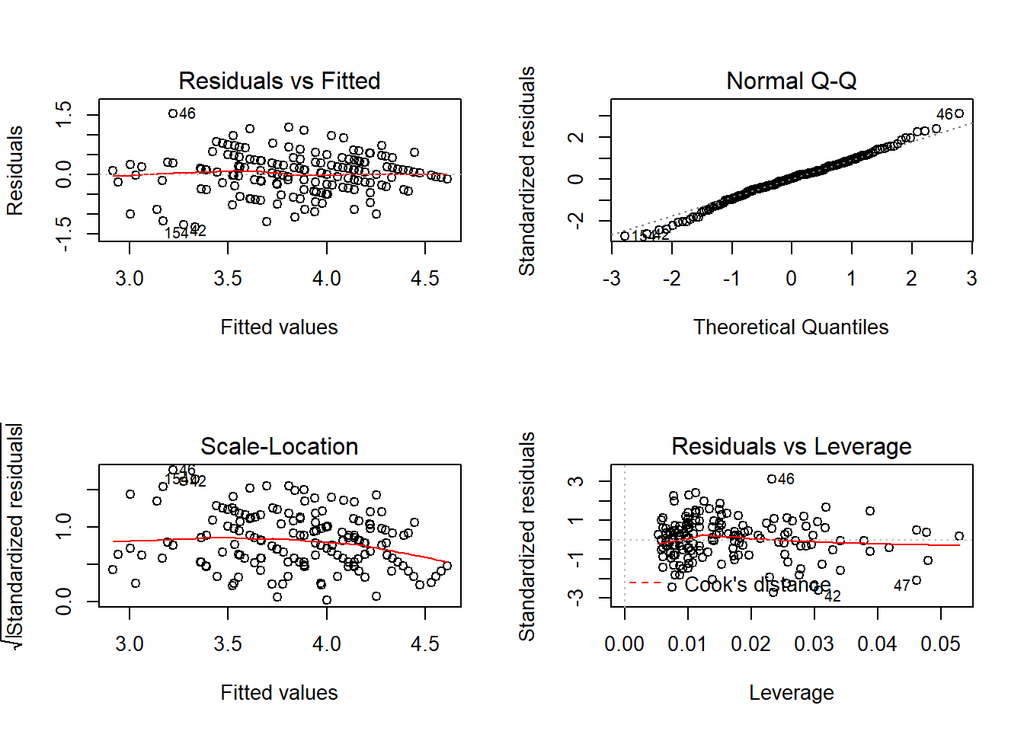

```r
# Modell schÃ¤tzen
modell.2 <- lm(gs.1 ~ ru.1 + wm.1, data = erstis)

# Residuenplots anfordern
par(mfrow = c(2, 2))
plot(modell.2)
```

Die Residuenplots sprechen nicht für eine Verletzung der Normalverteilungs- oder Homoskedastizitätsannahme. Auch Extremwerte werden nicht erkennbar.

```r
vif(modell.2)
```

```
##     ru.1     wm.1
## 1.150534 1.150534
```

Es liegt keine problematische MultikollinearitÃ¤t vor.

## Aufgabe 3: Modell 3

Nehmen Sie zusätzlich die Variable `neuro` als Prädiktor auf. Prüfen Sie, ob der Zuwachs des Determinationskoeffizienten *R*<sup>2</sup> signifikant ist, indem Sie einen *F*-Test durchführen. Tipp: Damit eine solche hierarchische Regressionsanalyse funktioniert, dürfen keine Personen mit fehlenden Werte auf den analysierten variablen im Data Frame enthalten sein.

```r
# Data Frame ohne fehlende Werte erstellen
auswahl <- na.omit(select(erstis, gs.1, ru.1, wm.1, neuro))

# Modelle anlegen
modell.2 <- lm(gs.1 ~ ru.1 + wm.1, data = auswahl)
modell.3 <- lm(gs.1 ~ ru.1 + wm.1 + neuro, data = auswahl)

# Zuwachs des Determinationskoeffizienten
summary(modell.3)$r.squared - summary(modell.2)$r.squared
```

```
## [1] 0.010616
```

```r
# Modellvergleich
anova(modell.2, modell.3)
```

```
## Analysis of Variance Table
##
## Model 1: gs.1 ~ ru.1 + wm.1
## Model 2: gs.1 ~ ru.1 + wm.1 + neuro
##   Res.Df    RSS Df Sum of Sq      F  Pr(>F)
## 1    185 45.792
## 2    184 45.042  1   0.74918 3.0604 0.08189 .
## ---
## Signif. codes:  0 '***' 0.001 '**' 0.01 '*' 0.05 '.' 0.1 ' ' 1
```

Der Modellvergleich wird nicht signifikant (*F*(1, 184) = 3.06, *p* = .082), d. h. das Modell mit mehr Prädiktoren kann nicht signifikant mehr Varianz der abhängigen Variablen erklären.